# **Análisis geoestadístico con `gstat`**

Máster en Data Science & Business Analytics (con R Software)

José-María Montero (jose.mlorenzo@uclm.es)  
Gema Fernández-Avilés (gema.faviles@uclm.es)

26-02-2022

*Nota*:

Se autoriza expresamente el uso de este material a la Universidad de Castilla-La Mancha para la docencia del [Máster en Data Science & Business Analytics (con R Software)](https://blog.uclm.es/tp-mbsba/programa/).

### Material:

- Diapositivas básicas para llevar a cabo R de un análisis geoestadítico con la librería `gstat`
- Videoclase explicativa del material proporcionado.

# Pasos de un análisis geoestadístico con `gstat`

#### Paso 1. Leemos los datos y preparamos el entormno. Creamos un objeto de la clase `sf` (`st_as_sf`)

#### Paso 2. ¿Existe algún tipo de dependencia espacial? Análisis exploratorio de datos espaciales

#### Paso 3. ¿Cómo es la estructura de la dependencia espacial? Semivariograma empírico

#### Paso 4. ¿Es mi semivariograma válido? Ajuste del semivariograma empírico al semivariograma teórico

#### Paso 5. ¿Puedo hacer predicciones en sitios donde no tenga datos de la variable que analizo? Kriging. Predicción y Desviación típica del error de predicción

#### Paso 6. Evaluación y presentación de resultados. Valiación cruzada. Mapping.

*Nota*:

Obsérvese que los pasos son idénticos en cualquier análisis geoestadístico, sea cual sea el programa o librería utilizados. Sólo cambia la estructura del objeto.

# Pasos de un análisis geoestadístico con `gstat`.

### Paso 1. Leemos los datos y convertimos a clase `sf`

```r
library(sf)
# `mydata_sf` es un objeto espacial: $coords y $data
mydata_sf <- st_as_sf(mydata,
  coords = c("longitud", "latitud"),
  crs = el_que_corresponda
)
```

```r
summary(mydata_sf)
plot(mydata_sf["nombre_variable"])

# alternativa:
ggplot() +
 geom_sf(
    data = mydata_sf,
    aes(color = nombre_variable)
  )
```

### Paso 3. Semivariograma empírico

```r
semivar_emp <- variogram(nombre_variable ~ 1, mydata_sf, cutoff = 1000000)
plot(semivar_emp)
```

### Paso 4. **Semivariograma teórico**

```r
semivar_teo # contiene los parámetros del semivariograma teórico
vgm(psill = NA, model, range = NA, nugget=NA
```

```r
* `model` = modelo de covarianza
* `psill` = varianza parcial
* `range` = rango o alcance
* `nugget` = nugget
```

### Paso 5. Kriging ordinario

```r
# creamos una malla de interopolación
# Una grid 5*5 km (25 km2)
grd_sf <- st_bbox(esp_utm) %>%
  st_as_sfc() %>%
  st_make_grid(
    cellsize = 5000,
    what = "centers"
  )
# Convert to sp object - interpolation should be made with sp/raster
grd <- as(grd_sf, "Spatial") %>%
  as("SpatialPixels")
```

```r
# Kriging ordinario
# help(krige)
tmin_ok <- krige(tmin ~ 1,
  tmin_8enero_sp,
  grd_sf,
  model = tmin_vgm_fit  ## semivar. teórico
)
```

### Paso 6. Evaluación y presentación de resultados. Mapping

```r
#varias funciones de mapeado
contour(krig_ord, filled = TRUE)
image(krig_ord, val = krig_ord$krige.var) #superficie de varianzas

# validación cruzada
mygeodata_xv <- xvalid(mygeodata, model = semivar_teo)
```

```r
library(plot3D)
# install.packages('plot3D')
persp3D(xx, yy, matrix(krig_ord$predict, nrow = length(xx)), theta=-60, phi=40)
```

# Caso de estudio: Interpolación de la temperatura mínima en España mediante kriging ordinario

Ejemplo tomado de **Pizarro M, Hernangómez D, Fernández-Avilés G (2021). *climaemet: Climate AEMET Tools*. doi: 10.5281/zenodo.5205573, http://hdl.handle.net/10261/250390**

[figure not shown]

### Paso 1. Leemos los datos y convertimos a clase `sf`

```r
# lectura de los datos y coordenadas
library(readr)
tmin <- read_csv("data/tempmin.csv")

# convertimos a un objeto sf
library(sf)
library(dplyr)

tmin_sf <- st_as_sf(tmin,
  coords = c("longitud", "latitud"),
  crs = 4258
)

tmin_8enero <- tmin_sf %>%
  filter(fecha == "2021-01-08")
```

### Paso 2. Análisis exploratorio de datos espaciales

```r
# descriptivos
summary(tmin_8enero)
```

```
##      fecha             indicativo             tmin                   geometry
##  Min.   :2021-01-08   Length:211         Min.   :-14.9000   POINT        :211
##  1st Qu.:2021-01-08   Class :character   1st Qu.: -4.6000   epsg:4258    :  0
##  Median :2021-01-08   Mode  :character   Median : -0.5000   +proj=long...:  0
##  Mean   :2021-01-08                      Mean   : -0.6294
##  3rd Qu.:2021-01-08                      3rd Qu.:  3.5000
##  Max.   :2021-01-08                      Max.   : 13.6000
```

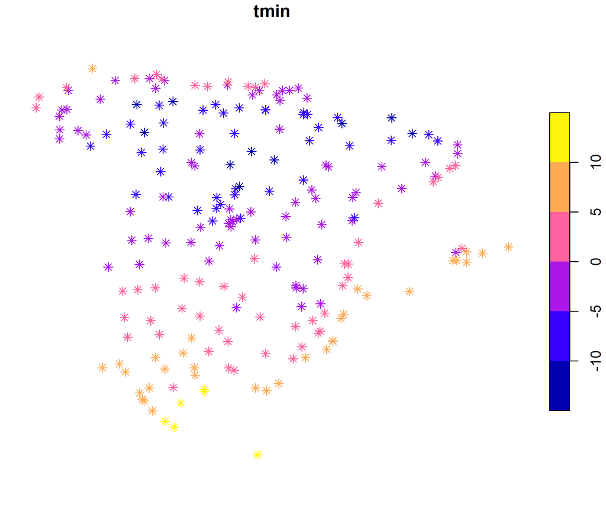

```r
# análisis gráfico
plot(tmin_8enero["tmin"],
  pch = 8
)
```

```r
# Mapa de temperatura mínima con geometrías

library(mapSpain)
# sf object
esp2 <- esp_get_ccaa() %>%
  # No vamos a usar Canarias en este análisis
  filter(ine.ccaa.name != "Canarias")

# comprobamos CRS
st_crs(tmin_sf) == st_crs(esp2)
```

```
## [1] TRUE
```

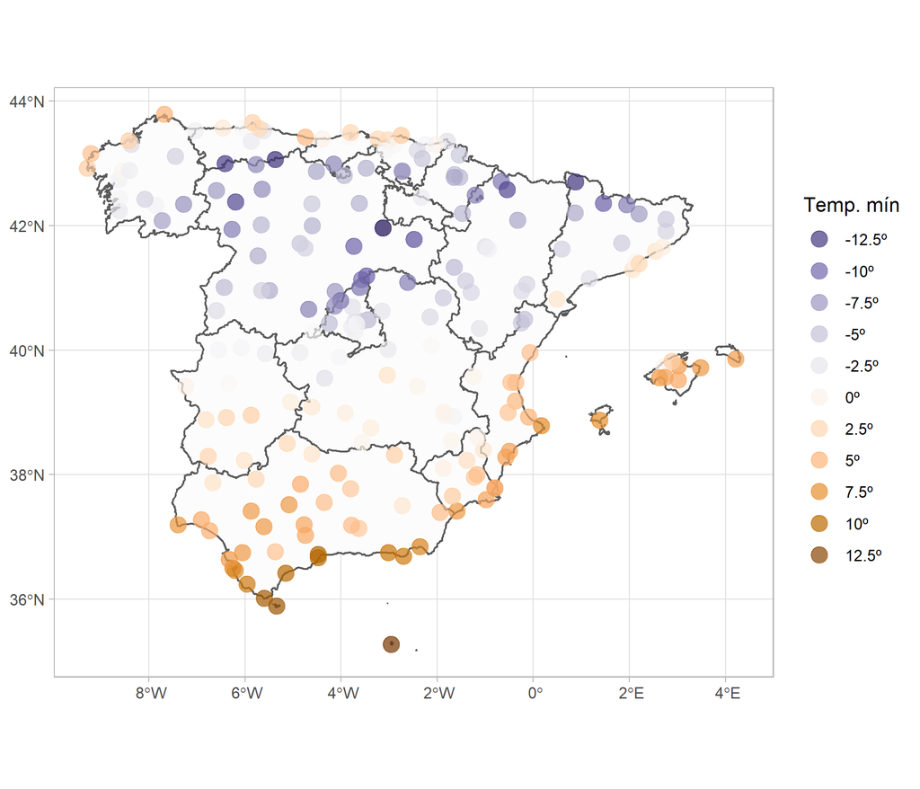

```r
# Especificamos la paleta de color a utilizar
cortes <- c(-Inf, seq(-20, 20, 2.5), Inf)
colores <- hcl.colors(15, "PuOr", rev = TRUE)



library(ggplot2)
ggplot() +
  geom_sf(
    data = esp2,
    fill = "grey99"
  ) +
  geom_sf(
    data = tmin_8enero,
    aes(color = tmin),
    size = 4,
    alpha = .7
  ) +
  labs(color = "Temp. mín") +
  scale_color_gradientn(
    colours = colores,
    breaks = cortes,
    labels = function(x) {
      paste0(x, "º")
    },
    guide = "legend"
  ) +
  theme_light() +
  theme(
    plot.title = element_text(
      size = 12,
      face = "bold"
    ),
    plot.subtitle = element_text(
      size = 8,
      face = "italic"
    )
  )
```

### Previo al paso 3 Comprobación de CRS y objeto espacial

#### `gstat::variogram()`

```r
tmin_8enero_utm <- st_transform(tmin_8enero, 25830)
esp_utm <- st_transform(esp2, 25830)
```

### Paso 3. Cálculo del semivariogram empírico

#### `gstat::variogram()`

```r
# Para la interpolación con gstat es necesarios cambiar a `sp`

library(sp)
tmin_8enero_sp <- as(tmin_8enero_utm, "Spatial")
tmin_8enero_sp <- st_as_sf(tmin_8enero_sp)
```

```r
# Directional empirical semivariogramin gstat()
library(gstat)
tmin_vgm_emp <- variogram(tmin ~ 1, tmin_8enero_sp, cutoff = 1000000)
tmin_vgm_emp
```

```
##      np     dist     gamma dir.hor dir.ver   id
## 1   483  44778.5  7.129586       0       0 var1
## 2  1124 101421.3 10.894204       0       0 var1
## 3  1539 167878.0 15.486400       0       0 var1
## 4  2001 234653.9 16.291237       0       0 var1
## 5  2356 300289.5 21.229595       0       0 var1
## 6  2516 366188.7 26.585640       0       0 var1
## 7  2363 433328.1 33.096437       0       0 var1
## 8  2262 499331.4 35.988952       0       0 var1
## 9  1998 566216.4 41.637352       0       0 var1
## 10 1652 632964.0 45.827915       0       0 var1
## 11 1396 699795.0 50.932858       0       0 var1
## 12 1085 764577.7 46.376553       0       0 var1
## 13  754 830301.2 50.989251       0       0 var1
## 14  376 896683.0 49.940186       0       0 var1
## 15  162 962649.8 49.412346       0       0 var1
```

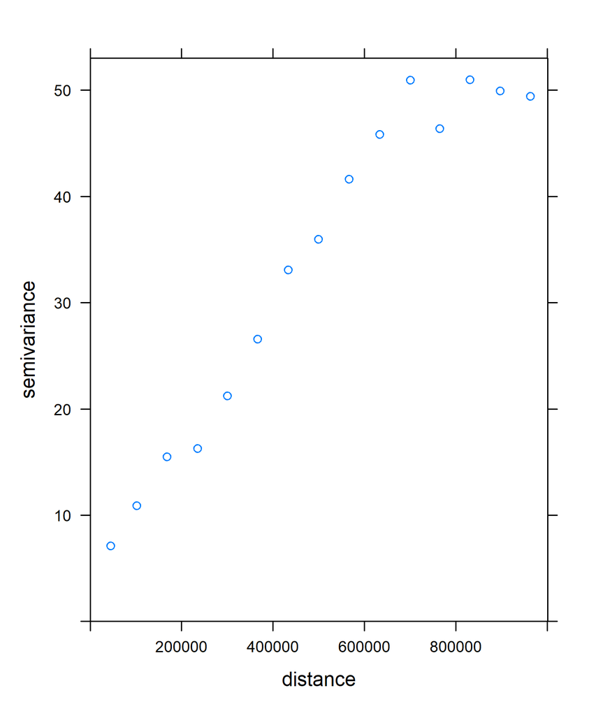

```r
plot(tmin_vgm_emp)
```

### Paso 4. Ajuste del semivariograma empírico a uno teoríco (spherical)

#### `gstat::fit.variogram()`

```r
tmin_vgm_fit <- fit.variogram(tmin_vgm_emp, # weighted least squares fit
  model = vgm(model = "Sph")  # vgm(psill = NA, model, range = NA, nugget=NA
)

tmin_vgm_fit
```

```
##   model    psill    range
## 1   Sph 47.77765 832076.5
```

### Representa ambos semivariogramas (empírico y teórico)

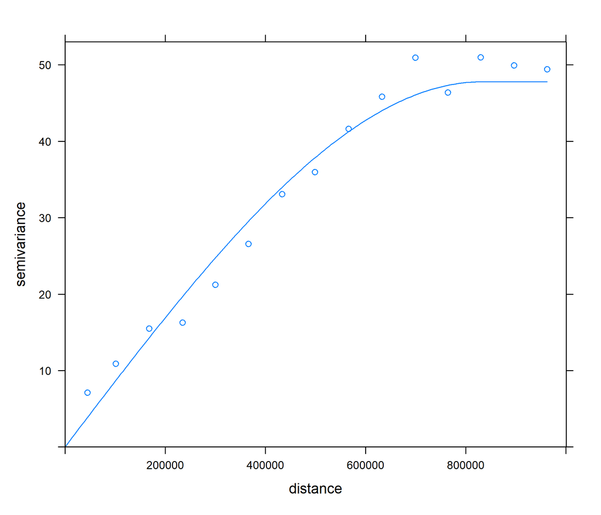

Semivariogramas empírico (puntos) y teórico (linea)

```r
# Plot empirical (dots) and theoretical (line) semivariograms
plot(tmin_vgm_emp, tmin_vgm_fit)
```

### Paso 5. Llevamos a cabo Kriging ordinario

##### gstat:: krige()

```r
# creamos una malla de interopolación
# Una grid 5*5 km (25 km2)
grd_sf <- st_bbox(esp_utm) %>%
  st_as_sfc() %>%
  st_make_grid(
    cellsize = 5000,
    what = "centers"
  )
# Convert to sp object - interpolation should be made with sp/raster
grd <- as(grd_sf, "Spatial") %>%
  as("SpatialPixels")
```

```r
# Kriging ordinario
tmin_ok <- krige(tmin ~ 1,
  tmin_8enero_sp,
  grd_sf,
  model = tmin_vgm_fit  ## semivar. teórico
)
```

```
## [using ordinary kriging]
```

### Paso 6. Evaluación y presentación de resultados. Mapping

```r
# Convertimos de sf a SpatiaPixels
# Esto funciona porque nuestros puntos sf están espaciados regularmente
library(dplyr)

tmin_pixels <- tmin_ok %>%
  as("Spatial") %>%
  as("SpatialPixels")


library(raster)
# Creamos un ráster de nuestros pixels
rast_esp <- raster(tmin_pixels)
```

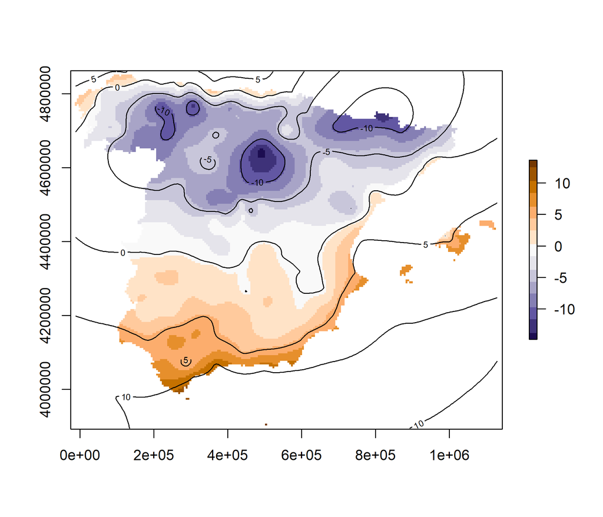

```r
# Transferimos valores del objeto sf al ráster
rast_esp_ok_pred <- rasterize(
  tmin_ok,
  rast_esp,
  field = "var1.pred", ## valores de predicción ok
  fun = mean
)

# Además, podemos recortar el ráster a la forma de España

rast_esp_mask <- mask(rast_esp_ok_pred, esp_utm)

plot(rast_esp_mask, col = colores)
contour(rast_esp_ok_pred, add = TRUE)
```

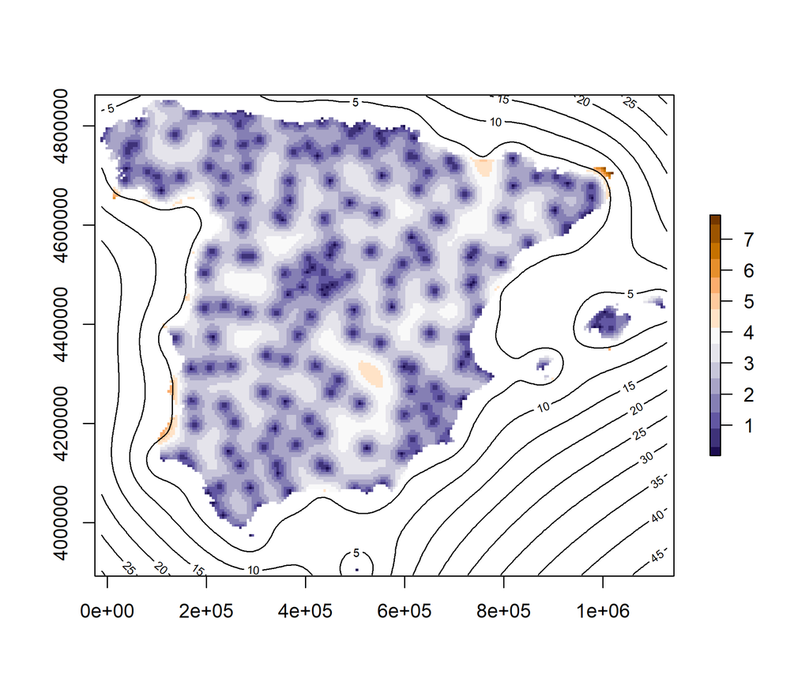

```r
# Convertimos de sf a SpatiaPixels
# Esto funciona porque nuestros puntos sf están espaciados regularmente

# Transferimos valores del objeto sf al ráster
rast_esp_ok_var <- rasterize(
  tmin_ok,
  rast_esp,
  field = "var1.var", ## valores de varianza de predicción
  fun = mean
)

# Además, podemos recortar el ráster a la forma de España

rast_esp_mask_ok_var <- mask(rast_esp_ok_var, esp_utm)

plot(rast_esp_mask_ok_var, col = colores)
contour(rast_esp_ok_var, add = TRUE)
```